# NORC Initial Report

Jacob Copple

9/9/2020

## Initial Report for GFK Survey

This report includes all relevant information for preliminary descriptive data on the items asked as a part of the GFK survey distributed and collected summer of 2020. The data is organized to display the summary statistic measures of goals, objectives and tactics related to science communication and engagement. Then select demographic information is grouped within the summary statistics to provide more inside. Finally, potential factors that could be used as factors predicting approval of scientists who are more/less strategic with their communication.

##### Importing and Labeling Data

Import cleaned dataset filtered for variables important to the current report. Included packages are listed at the top and should be run first and in the order in which they appear.

Select and create labels for each variable of interest.

### Descriptive Statistics

Below are all the summary statistics for all variables of interest.

|  | N |  | Mean | SD |  | Min | Q1 | Median | Q3 | Max |
| --- | --- | --- | --- | --- | --- | --- | --- | --- | --- | --- |
| G_funding | 1010 |  | 3.89 | 0.92 |  | 1 | 3.00 | 4.0 | 5.00 | 5 |
| G_policy | 1010 |  | 4.04 | 0.89 |  | 1 | 4.00 | 4.0 | 5.00 | 5 |
| G_advocate | 1010 |  | 3.81 | 0.87 |  | 1 | 3.00 | 4.0 | 4.00 | 5 |
| G_culture | 1010 |  | 3.90 | 0.90 |  | 1 | 3.00 | 4.0 | 5.00 | 5 |
| G_recruit | 1010 |  | 3.80 | 0.91 |  | 1 | 3.00 | 4.0 | 4.00 | 5 |
| G_personal | 1010 |  | 4.02 | 0.85 |  | 1 | 4.00 | 4.0 | 5.00 | 5 |
| G_society | 1010 |  | 3.89 | 0.87 |  | 1 | 3.00 | 4.0 | 5.00 | 5 |
| G_rep | 1010 |  | 3.07 | 1.06 |  | 1 | 2.00 | 3.0 | 4.00 | 5 |
| G_questions | 1010 |  | 3.91 | 0.83 |  | 1 | 3.00 | 4.0 | 4.00 | 5 |
| O_inform | 1010 |  | 4.15 | 0.77 |  | 1 | 4.00 | 4.0 | 5.00 | 5 |
| O_excite | 1010 |  | 3.87 | 0.86 |  | 1 | 3.00 | 4.0 | 4.00 | 5 |
| O_listen | 1010 |  | 3.78 | 0.88 |  | 1 | 3.00 | 4.0 | 4.00 | 5 |
| O_open | 1010 |  | 3.98 | 0.84 |  | 1 | 3.00 | 4.0 | 5.00 | 5 |
| O_care | 1010 |  | 3.93 | 0.87 |  | 1 | 3.00 | 4.0 | 5.00 | 5 |
| O_expert | 1010 |  | 3.90 | 0.86 |  | 1 | 3.00 | 4.0 | 5.00 | 5 |
| O_discredit | 1010 |  | 3.99 | 0.98 |  | 1 | 3.00 | 4.0 | 5.00 | 5 |
| O_action | 1010 |  | 3.97 | 0.82 |  | 1 | 3.00 | 4.0 | 5.00 | 5 |
| T_connect | 1010 |  | 4.05 | 0.83 |  | 1 | 4.00 | 4.0 | 5.00 | 5 |
| T_story | 1010 |  | 3.29 | 0.92 |  | 1 | 3.00 | 3.0 | 4.00 | 5 |
| T_reveal | 1010 |  | 3.32 | 0.92 |  | 1 | 3.00 | 3.0 | 4.00 | 5 |
| T_listen | 1010 |  | 3.83 | 0.85 |  | 1 | 3.00 | 4.0 | 4.00 | 5 |
| T_community | 1010 |  | 3.91 | 0.86 |  | 1 | 3.00 | 4.0 | 4.00 | 5 |
| T_disagree | 1010 |  | 3.12 | 1.10 |  | 1 | 2.00 | 3.0 | 4.00 | 5 |
| T_angry | 1010 |  | 2.20 | 0.96 |  | 1 | 2.00 | 2.0 | 3.00 | 5 |
| T_hope | 1010 |  | 3.71 | 0.88 |  | 1 | 3.00 | 4.0 | 4.00 | 5 |
| T_disclose | 1010 |  | 3.87 | 0.94 |  | 1 | 3.00 | 4.0 | 5.00 | 5 |
| T_open | 1010 |  | 3.92 | 0.72 |  | 1 | 3.33 | 4.0 | 4.33 | 5 |
| T_aggressive | 1010 |  | 2.66 | 0.82 |  | 1 | 2.00 | 2.5 | 3.00 | 5 |
| qualified | 1010 |  | 4.19 | 0.93 |  | 1 | 4.00 | 4.0 | 5.00 | 5 |
| experience | 1010 |  | 4.00 | 0.95 |  | 1 | 3.00 | 4.0 | 5.00 | 5 |
| honest | 1010 |  | 3.81 | 1.02 |  | 1 | 3.00 | 4.0 | 5.00 | 5 |
| sincere | 1010 |  | 3.78 | 1.01 |  | 1 | 3.00 | 4.0 | 5.00 | 5 |
| ethical | 1010 |  | 3.80 | 1.01 |  | 1 | 3.00 | 4.0 | 5.00 | 5 |
| moral | 1010 |  | 3.70 | 0.97 |  | 1 | 3.00 | 4.0 | 4.00 | 5 |
| warm | 1010 |  | 3.23 | 0.92 |  | 1 | 3.00 | 3.0 | 4.00 | 5 |
| sciatt_1 | 1010 |  | 4.14 | 0.82 |  | 1 | 4.00 | 4.0 | 5.00 | 5 |
| sciatt_2 | 1010 |  | 3.95 | 0.88 |  | 1 | 3.00 | 4.0 | 5.00 | 5 |
| SciAtt | 1010 |  | 4.03 | 0.78 |  | 1 | 3.50 | 4.0 | 4.50 | 5 |
| jlism | 1010 |  | 2.58 | 1.11 |  | 1 | 2.00 | 3.0 | 3.00 | 5 |
| audio | 1010 |  | 2.23 | 1.07 |  | 1 | 1.00 | 2.0 | 3.00 | 5 |
| TV | 1010 |  | 2.88 | 1.08 |  | 1 | 2.00 | 3.0 | 4.00 | 5 |
| SNS | 1010 |  | 2.54 | 1.09 |  | 1 | 2.00 | 3.0 | 3.00 | 5 |
| mode_online | 1010 |  | 3.60 | 1.10 |  | 1 | 3.00 | 4.0 | 5.00 | 5 |
| mode_face | 1010 |  | 3.97 | 1.01 |  | 1 | 3.00 | 4.0 | 5.00 | 5 |
| mode_jlism | 1010 |  | 3.98 | 1.01 |  | 1 | 3.00 | 4.0 | 5.00 | 5 |
| mode_policy | 1010 |  | 3.88 | 1.10 |  | 1 | 3.00 | 4.0 | 5.00 | 5 |
| mode_protest | 1010 |  | 3.08 | 1.25 |  | 1 | 2.00 | 3.0 | 4.00 | 5 |
| training | 1010 |  | 3.58 | 0.88 |  | 1 | 3.00 | 4.0 | 4.00 | 5 |
| worktime | 1010 |  | 3.46 | 0.88 |  | 1 | 3.00 | 3.0 | 4.00 | 5 |
| know_fossil | 1010 |  | 0.62 | 0.49 |  | 0 | 0.00 | 1.0 | 1.00 | 1 |
| know_anti | 1010 |  | 0.51 | 0.50 |  | 0 | 0.00 | 1.0 | 1.00 | 1 |
| sciknow | 1010 |  | 0.57 | 0.40 |  | 0 | 0.00 | 0.5 | 1.00 | 1 |
| EDUC5 | 1010 |  | 3.23 | 1.07 |  | 1 | 3.00 | 3.0 | 4.00 | 5 |
| P_IDEO | 1010 |  | 4.41 | 2.01 |  | 1 | 3.00 | 4.0 | 6.00 | 8 |
| HOME_TYPE | 1010 |  | 1.66 | 0.97 |  | 1 | 1.00 | 1.0 | 3.00 | 5 |
| RACETHNICITY | 1010 |  | 1.91 | 1.48 |  | 1 | 1.00 | 1.0 | 2.00 | 6 |
| GENDER | 1010 |  | 1.53 | 0.50 |  | 1 | 1.00 | 2.0 | 2.00 | 2 |
| AGE | 1010 |  | 47.63 | 16.97 |  | 18 | 33.00 | 46.0 | 61.00 | 95 |
| INCOME | 1010 |  | 9.92 | 4.13 |  | 1 | 7.00 | 10.0 | 13.00 | 18 |

#### Demographics

##### Age

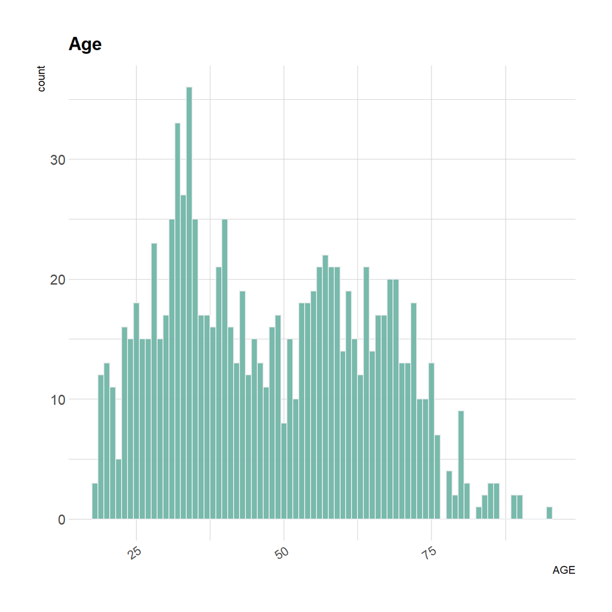

|  | N |  | Mean | SD |  | Min | Q1 | Median | Q3 | Max |
| --- | --- | --- | --- | --- | --- | --- | --- | --- | --- | --- |
| AGE | 1010 |  | 47.63 | 16.97 |  | 18 | 33 | 46 | 61 | 95 |

##### Education

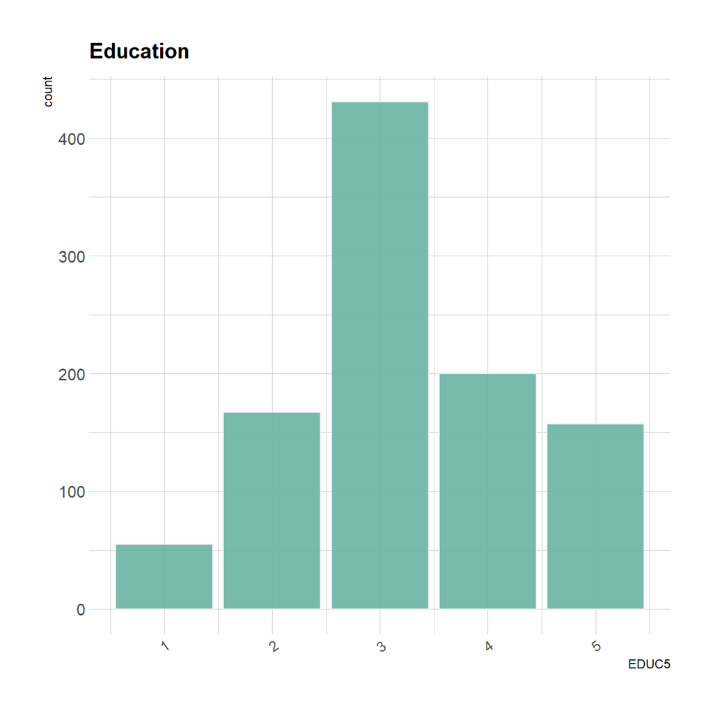

|  | N |  | Mean | SD |  | Min | Q1 | Median | Q3 | Max |
| --- | --- | --- | --- | --- | --- | --- | --- | --- | --- | --- |
| EDUC5 | 1010 |  | 3.23 | 1.07 |  | 1 | 3 | 3 | 4 | 5 |

##### Race & Ethnicity

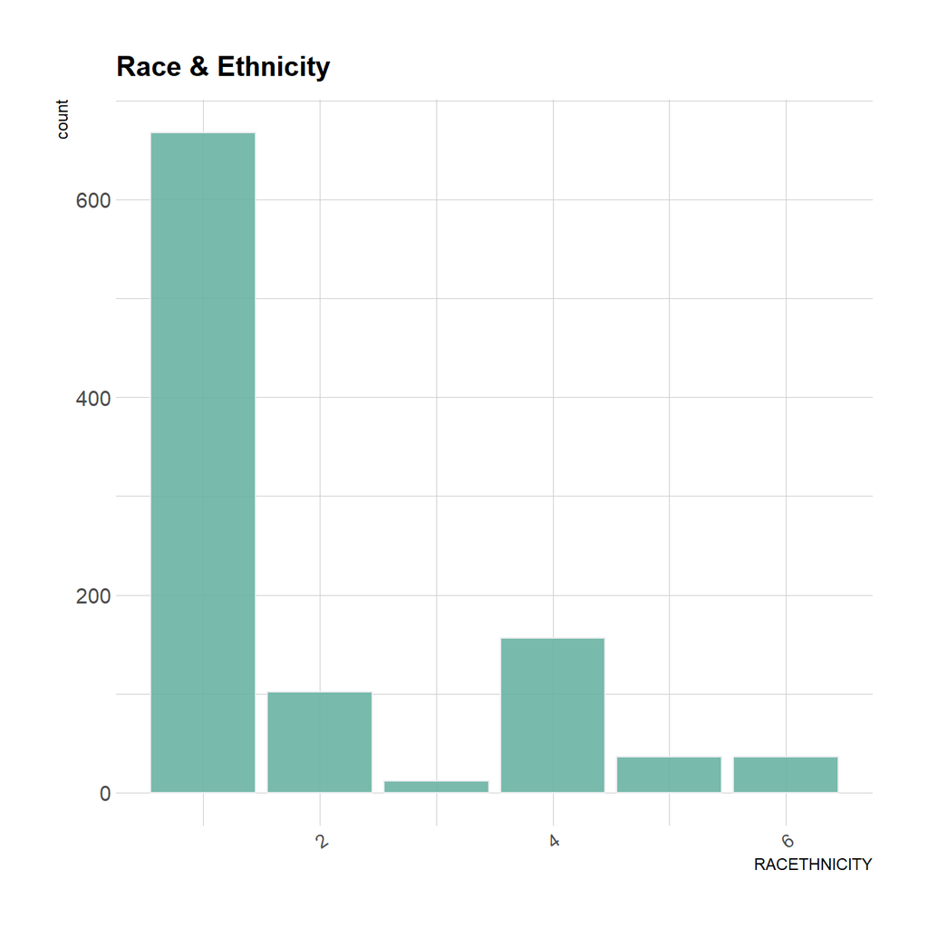

|  | N |  | Mean | SD |  | Min | Q1 | Median | Q3 | Max |
| --- | --- | --- | --- | --- | --- | --- | --- | --- | --- | --- |
| RACETHNICITY | 1010 |  | 1.91 | 1.48 |  | 1 | 1 | 1 | 2 | 6 |

##### Political Ideology

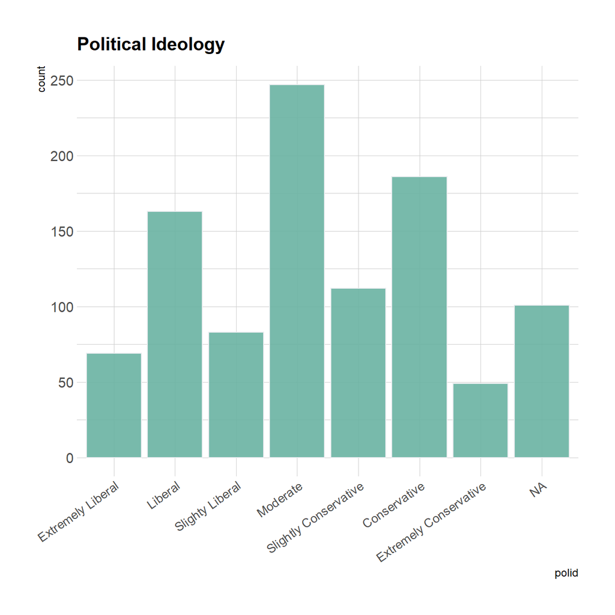

|  | N |  | Mean | SD |  | Min | Q1 | Median | Q3 | Max |
| --- | --- | --- | --- | --- | --- | --- | --- | --- | --- | --- |
| P_IDEO | 1010 |  | 4.41 | 2.01 |  | 1 | 3 | 4 | 6 | 8 |

##### Income

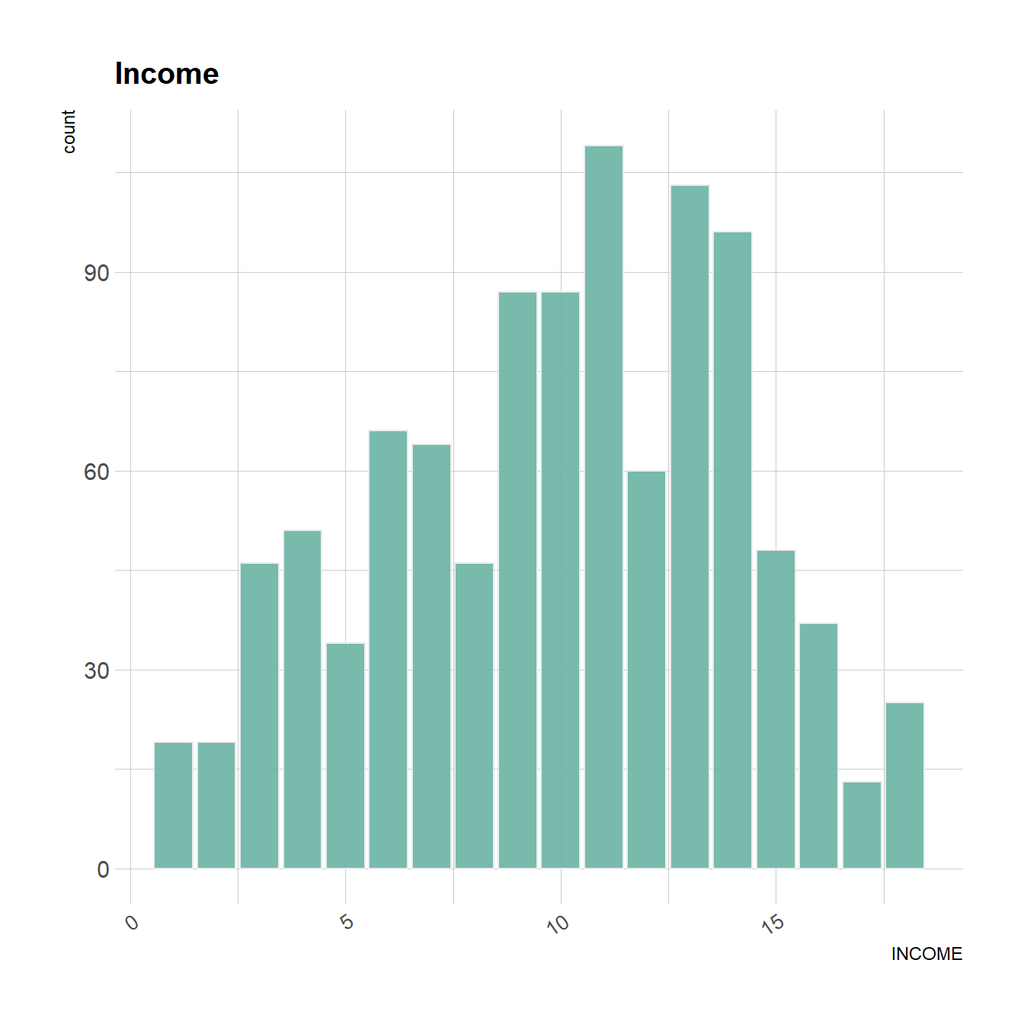

|  | N |  | Mean | SD |  | Min | Q1 | Median | Q3 | Max |
| --- | --- | --- | --- | --- | --- | --- | --- | --- | --- | --- |
| INCOME | 1010 |  | 9.92 | 4.13 |  | 1 | 7 | 10 | 13 | 18 |

##### Gender

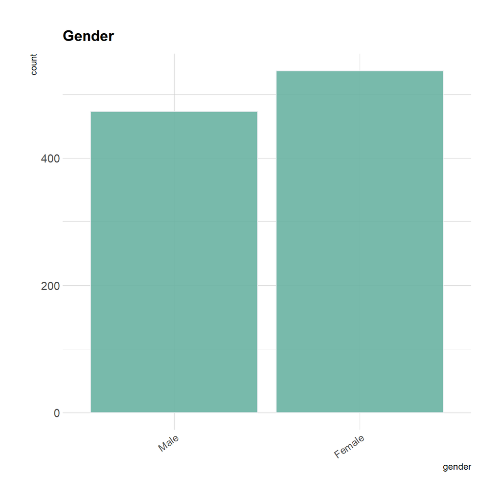

|  | N |  | Mean | SD |  | Min | Q1 | Median | Q3 | Max |
| --- | --- | --- | --- | --- | --- | --- | --- | --- | --- | --- |
| GENDER | 1010 |  | 1.53 | 0.5 |  | 1 | 1 | 2 | 2 | 2 |

#### Science Dependend Variables

##### Goals

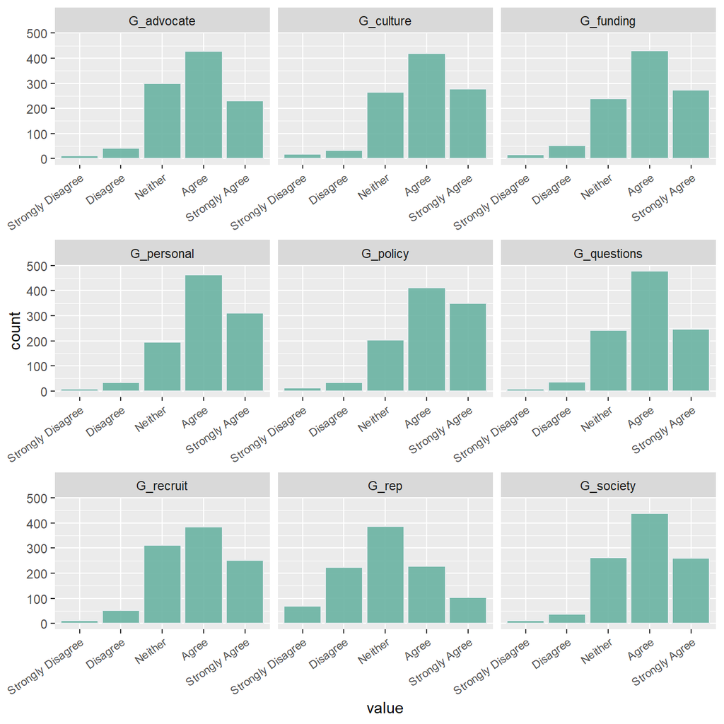

|  | N |  | Mean | SD |  | Min | Q1 | Median | Q3 | Max |
| --- | --- | --- | --- | --- | --- | --- | --- | --- | --- | --- |
| G_funding | 1010 |  | 3.89 | 0.92 |  | 1 | 3 | 4 | 5 | 5 |
| G_policy | 1010 |  | 4.04 | 0.89 |  | 1 | 4 | 4 | 5 | 5 |
| G_advocate | 1010 |  | 3.81 | 0.87 |  | 1 | 3 | 4 | 4 | 5 |
| G_culture | 1010 |  | 3.90 | 0.90 |  | 1 | 3 | 4 | 5 | 5 |
| G_recruit | 1010 |  | 3.80 | 0.91 |  | 1 | 3 | 4 | 4 | 5 |
| G_personal | 1010 |  | 4.02 | 0.85 |  | 1 | 4 | 4 | 5 | 5 |
| G_society | 1010 |  | 3.89 | 0.87 |  | 1 | 3 | 4 | 5 | 5 |
| G_rep | 1010 |  | 3.07 | 1.06 |  | 1 | 2 | 3 | 4 | 5 |
| G_questions | 1010 |  | 3.91 | 0.83 |  | 1 | 3 | 4 | 4 | 5 |

##### Objectives

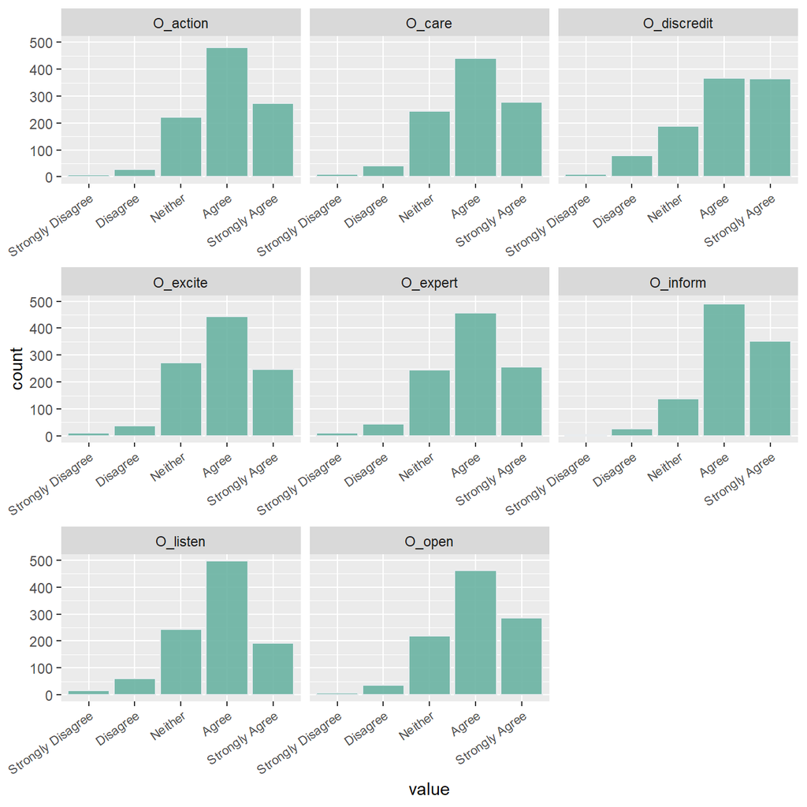

|  | N |  | Mean | SD |  | Min | Q1 | Median | Q3 | Max |
| --- | --- | --- | --- | --- | --- | --- | --- | --- | --- | --- |
| O_inform | 1010 |  | 4.15 | 0.77 |  | 1 | 4 | 4 | 5 | 5 |
| O_excite | 1010 |  | 3.87 | 0.86 |  | 1 | 3 | 4 | 4 | 5 |
| O_listen | 1010 |  | 3.78 | 0.88 |  | 1 | 3 | 4 | 4 | 5 |
| O_open | 1010 |  | 3.98 | 0.84 |  | 1 | 3 | 4 | 5 | 5 |
| O_care | 1010 |  | 3.93 | 0.87 |  | 1 | 3 | 4 | 5 | 5 |
| O_expert | 1010 |  | 3.90 | 0.86 |  | 1 | 3 | 4 | 5 | 5 |
| O_discredit | 1010 |  | 3.99 | 0.98 |  | 1 | 3 | 4 | 5 | 5 |
| O_action | 1010 |  | 3.97 | 0.82 |  | 1 | 3 | 4 | 5 | 5 |

##### Tactics

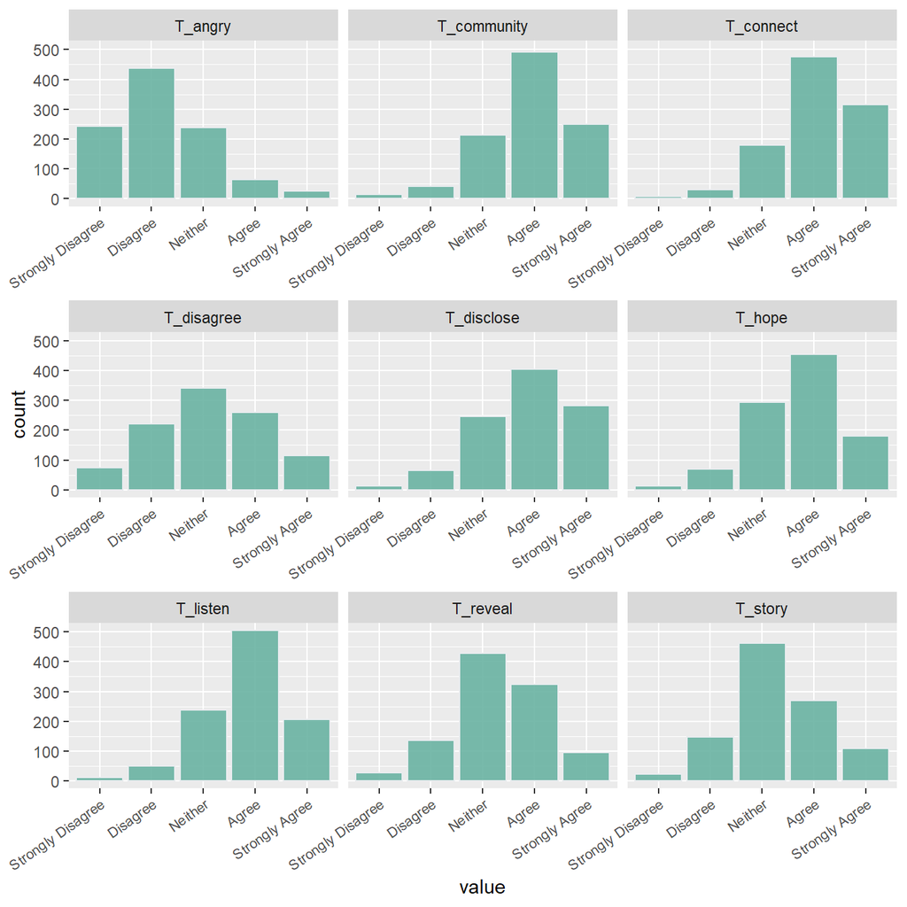

|  | N |  | Mean | SD |  | Min | Q1 | Median | Q3 | Max |
| --- | --- | --- | --- | --- | --- | --- | --- | --- | --- | --- |
| T_connect | 1010 |  | 4.05 | 0.83 |  | 1 | 4.00 | 4.0 | 5.00 | 5 |
| T_story | 1010 |  | 3.29 | 0.92 |  | 1 | 3.00 | 3.0 | 4.00 | 5 |
| T_reveal | 1010 |  | 3.32 | 0.92 |  | 1 | 3.00 | 3.0 | 4.00 | 5 |
| T_listen | 1010 |  | 3.83 | 0.85 |  | 1 | 3.00 | 4.0 | 4.00 | 5 |
| T_community | 1010 |  | 3.91 | 0.86 |  | 1 | 3.00 | 4.0 | 4.00 | 5 |
| T_disagree | 1010 |  | 3.12 | 1.10 |  | 1 | 2.00 | 3.0 | 4.00 | 5 |
| T_angry | 1010 |  | 2.20 | 0.96 |  | 1 | 2.00 | 2.0 | 3.00 | 5 |
| T_hope | 1010 |  | 3.71 | 0.88 |  | 1 | 3.00 | 4.0 | 4.00 | 5 |
| T_disclose | 1010 |  | 3.87 | 0.94 |  | 1 | 3.00 | 4.0 | 5.00 | 5 |
| T_open | 1010 |  | 3.92 | 0.72 |  | 1 | 3.33 | 4.0 | 4.33 | 5 |
| T_aggressive | 1010 |  | 2.66 | 0.82 |  | 1 | 2.00 | 2.5 | 3.00 | 5 |

##### Mode of Engagement

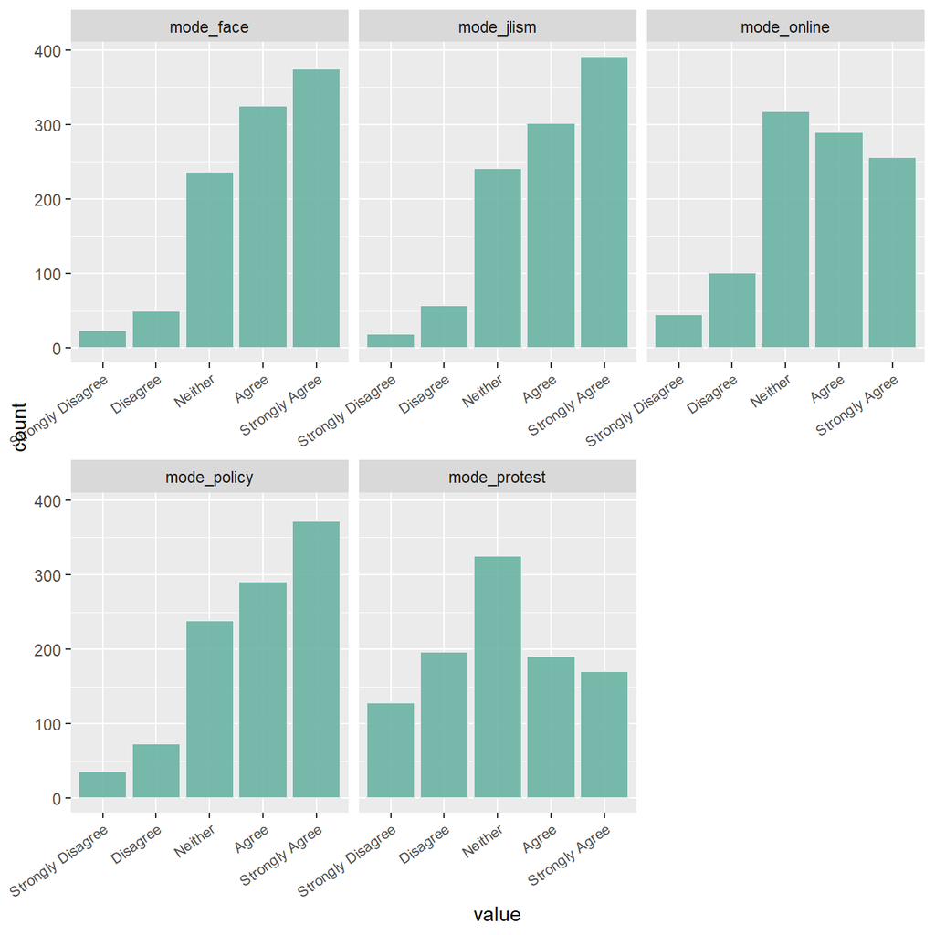

|  | N |  | Mean | SD |  | Min | Q1 | Median | Q3 | Max |
| --- | --- | --- | --- | --- | --- | --- | --- | --- | --- | --- |
| mode_online | 1010 |  | 3.60 | 1.10 |  | 1 | 3 | 4 | 5 | 5 |
| mode_face | 1010 |  | 3.97 | 1.01 |  | 1 | 3 | 4 | 5 | 5 |
| mode_jlism | 1010 |  | 3.98 | 1.01 |  | 1 | 3 | 4 | 5 | 5 |
| mode_policy | 1010 |  | 3.88 | 1.10 |  | 1 | 3 | 4 | 5 | 5 |
| mode_protest | 1010 |  | 3.08 | 1.25 |  | 1 | 2 | 3 | 4 | 5 |

#### Potential Independent Variables

##### METI

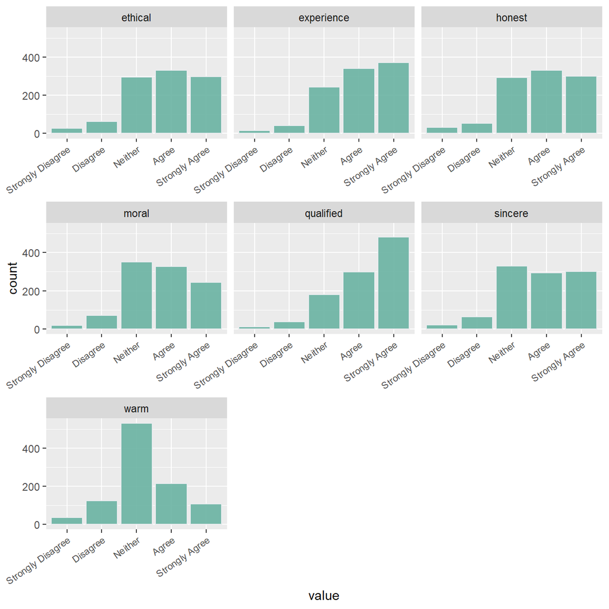

|  | N |  | Mean | SD |  | Min | Q1 | Median | Q3 | Max |
| --- | --- | --- | --- | --- | --- | --- | --- | --- | --- | --- |
| qualified | 1010 |  | 4.19 | 0.93 |  | 1 | 4 | 4 | 5 | 5 |
| experience | 1010 |  | 4.00 | 0.95 |  | 1 | 3 | 4 | 5 | 5 |
| honest | 1010 |  | 3.81 | 1.02 |  | 1 | 3 | 4 | 5 | 5 |
| sincere | 1010 |  | 3.78 | 1.01 |  | 1 | 3 | 4 | 5 | 5 |
| ethical | 1010 |  | 3.80 | 1.01 |  | 1 | 3 | 4 | 5 | 5 |
| moral | 1010 |  | 3.70 | 0.97 |  | 1 | 3 | 4 | 4 | 5 |
| warm | 1010 |  | 3.23 | 0.92 |  | 1 | 3 | 3 | 4 | 5 |

##### Science Attitudes

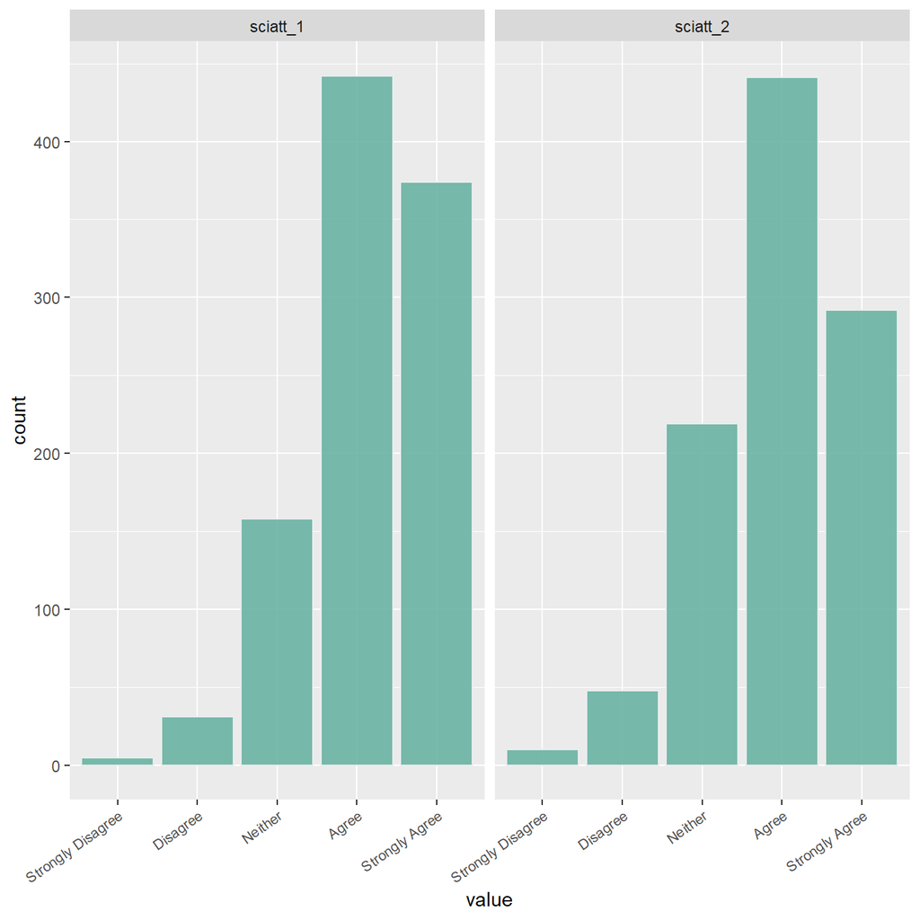

|  | N |  | Mean | SD |  | Min | Q1 | Median | Q3 | Max |
| --- | --- | --- | --- | --- | --- | --- | --- | --- | --- | --- |
| sciatt_1 | 1010 |  | 4.14 | 0.82 |  | 1 | 4.0 | 4 | 5.0 | 5 |
| sciatt_2 | 1010 |  | 3.95 | 0.88 |  | 1 | 3.0 | 4 | 5.0 | 5 |
| SciAtt | 1010 |  | 4.03 | 0.78 |  | 1 | 3.5 | 4 | 4.5 | 5 |

##### Science Media

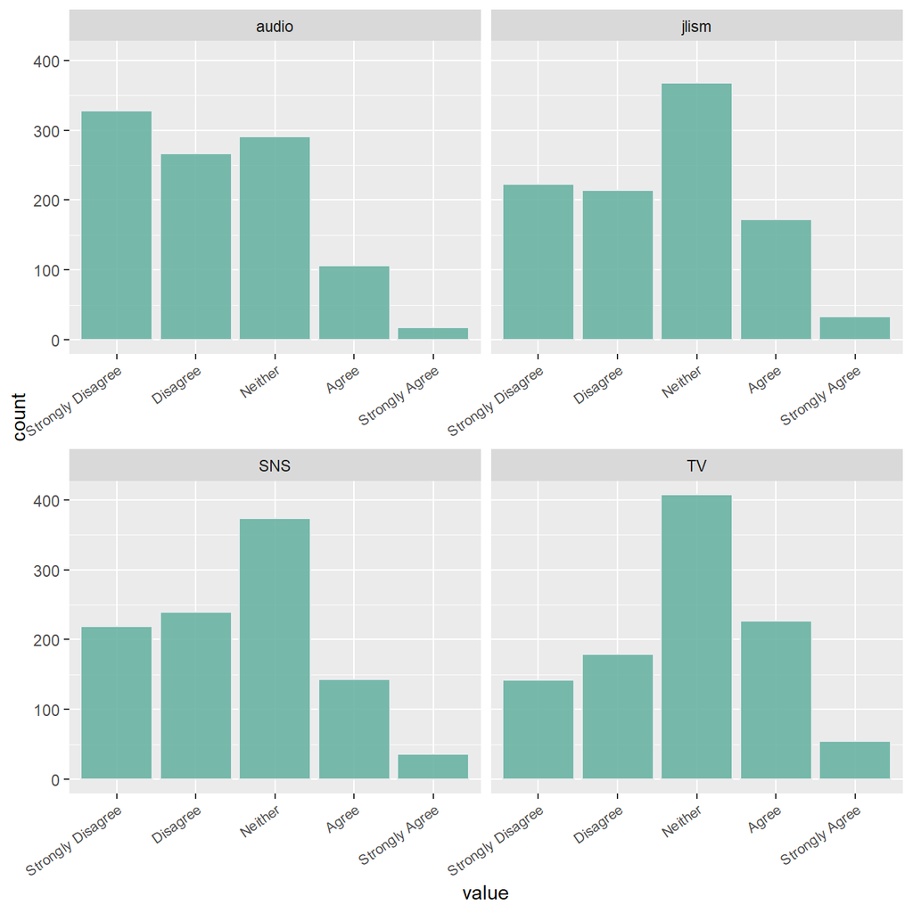

|  | N |  | Mean | SD |  | Min | Q1 | Median | Q3 | Max |
| --- | --- | --- | --- | --- | --- | --- | --- | --- | --- | --- |
| jlism | 1010 |  | 2.58 | 1.11 |  | 1 | 2 | 3 | 3 | 5 |
| audio | 1010 |  | 2.23 | 1.07 |  | 1 | 1 | 2 | 3 | 5 |
| TV | 1010 |  | 2.88 | 1.08 |  | 1 | 2 | 3 | 4 | 5 |
| SNS | 1010 |  | 2.54 | 1.09 |  | 1 | 2 | 3 | 3 | 5 |

##### Communication Development

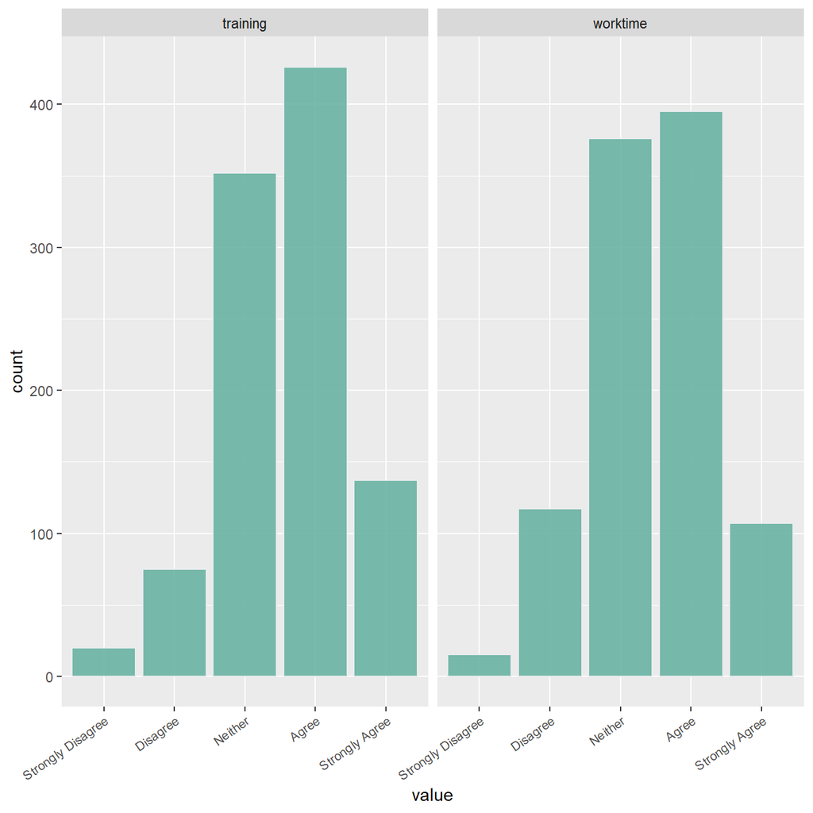

|  | N |  | Mean | SD |  | Min | Q1 | Median | Q3 | Max |
| --- | --- | --- | --- | --- | --- | --- | --- | --- | --- | --- |
| training | 1010 |  | 3.58 | 0.88 |  | 1 | 3 | 4 | 4 | 5 |
| worktime | 1010 |  | 3.46 | 0.88 |  | 1 | 3 | 3 | 4 | 5 |

##### Science Knowledge

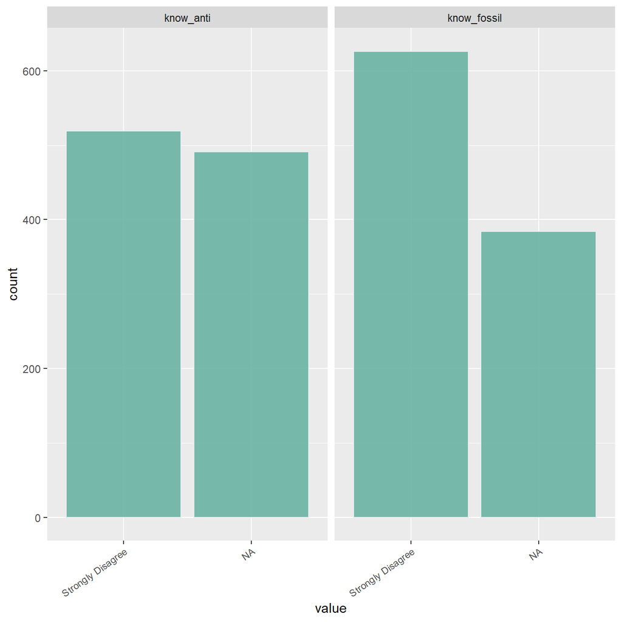

|  | N |  | Mean | SD |  | Min | Q1 | Median | Q3 | Max |
| --- | --- | --- | --- | --- | --- | --- | --- | --- | --- | --- |
| know_fossil | 1010 |  | 0.62 | 0.49 |  | 0 | 0 | 1.0 | 1 | 1 |
| know_anti | 1010 |  | 0.51 | 0.50 |  | 0 | 0 | 1.0 | 1 | 1 |
| sciknow | 1010 |  | 0.57 | 0.40 |  | 0 | 0 | 0.5 | 1 | 1 |

### CrossTabs

Below are the cross tabulations for key demographics and potential dependent variables

#### Age

The Following charts are organized by age groups recorded from survey respondents. Acceptance/approval of science communication goals, objectives, and tactics are also included as well as variables on epistemic trustworthiness.

##### Goals

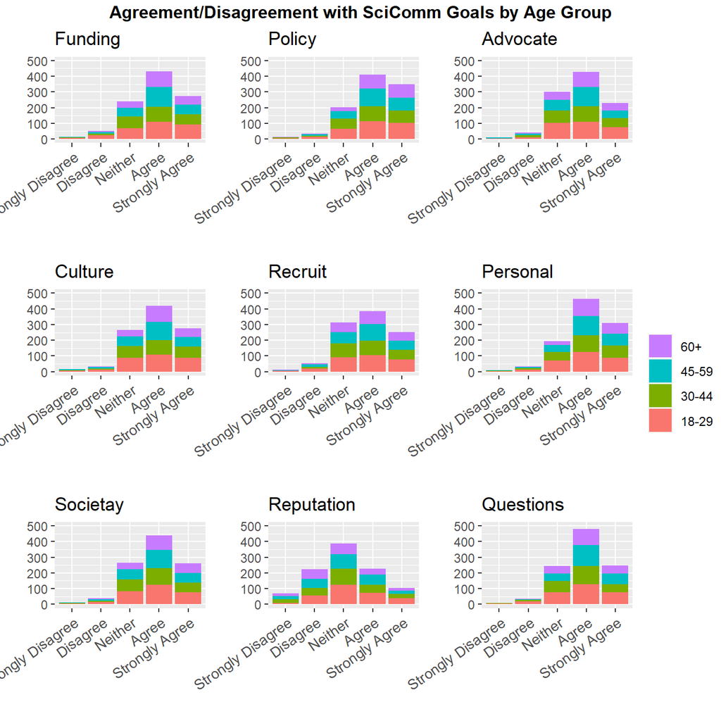

##### Objectives

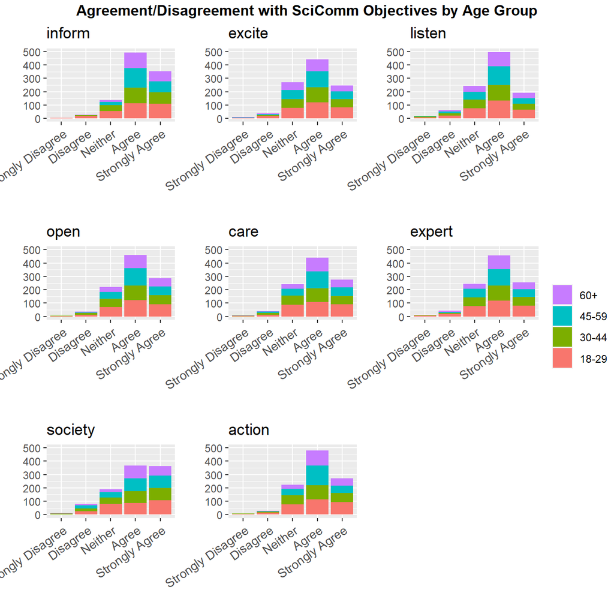

##### Tactics

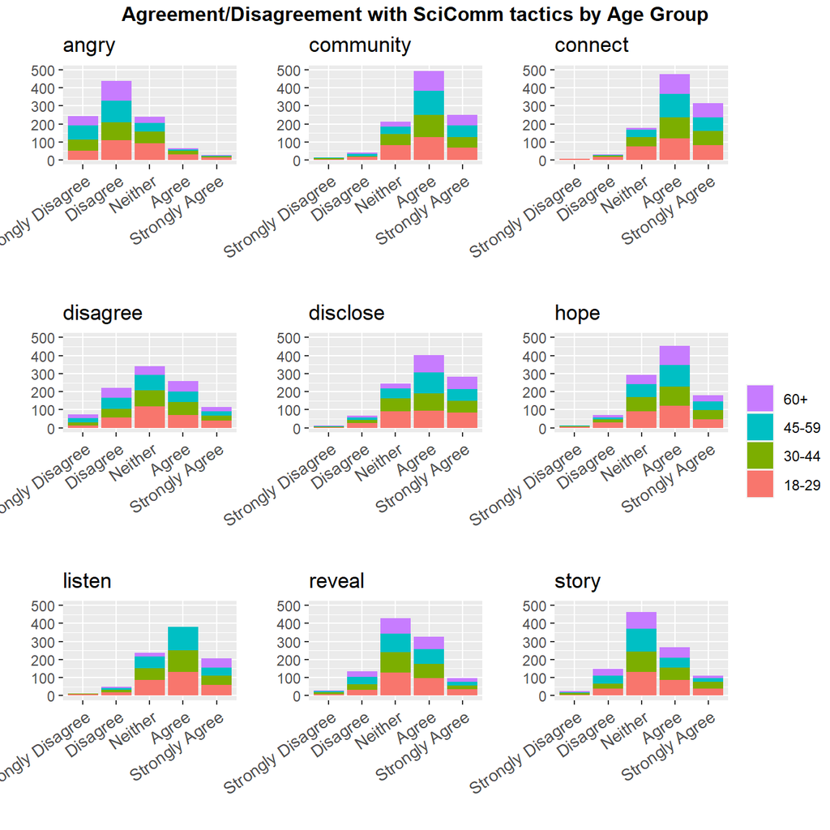

##### METI

Muenster Epistemic Trustworthiness Index

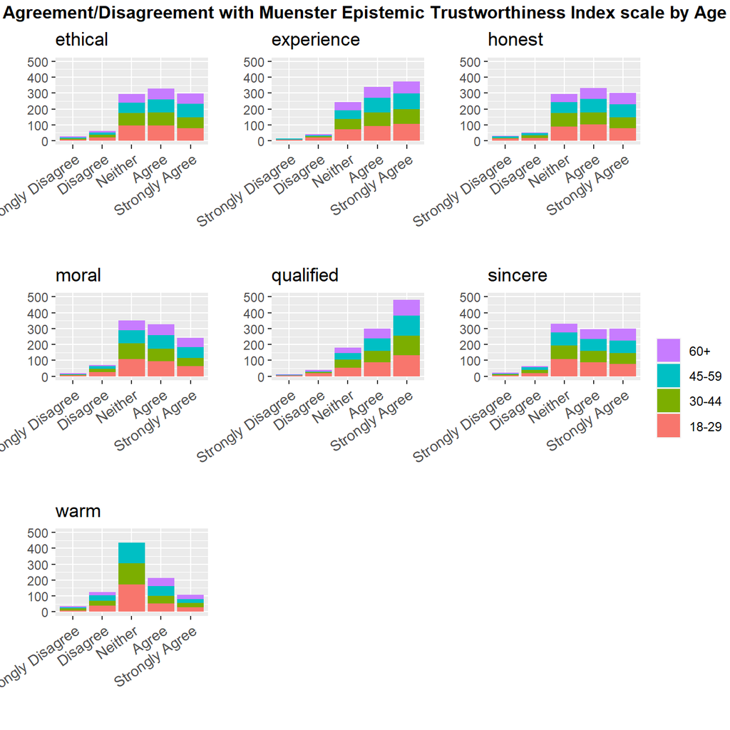

##### Science Media

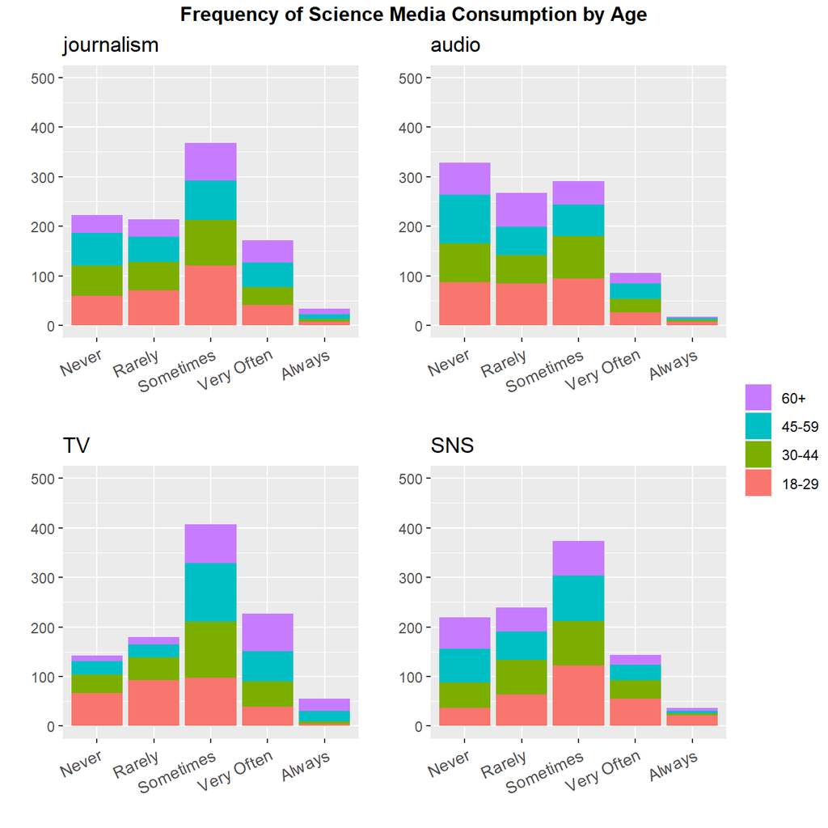

##### Mode of Engagement

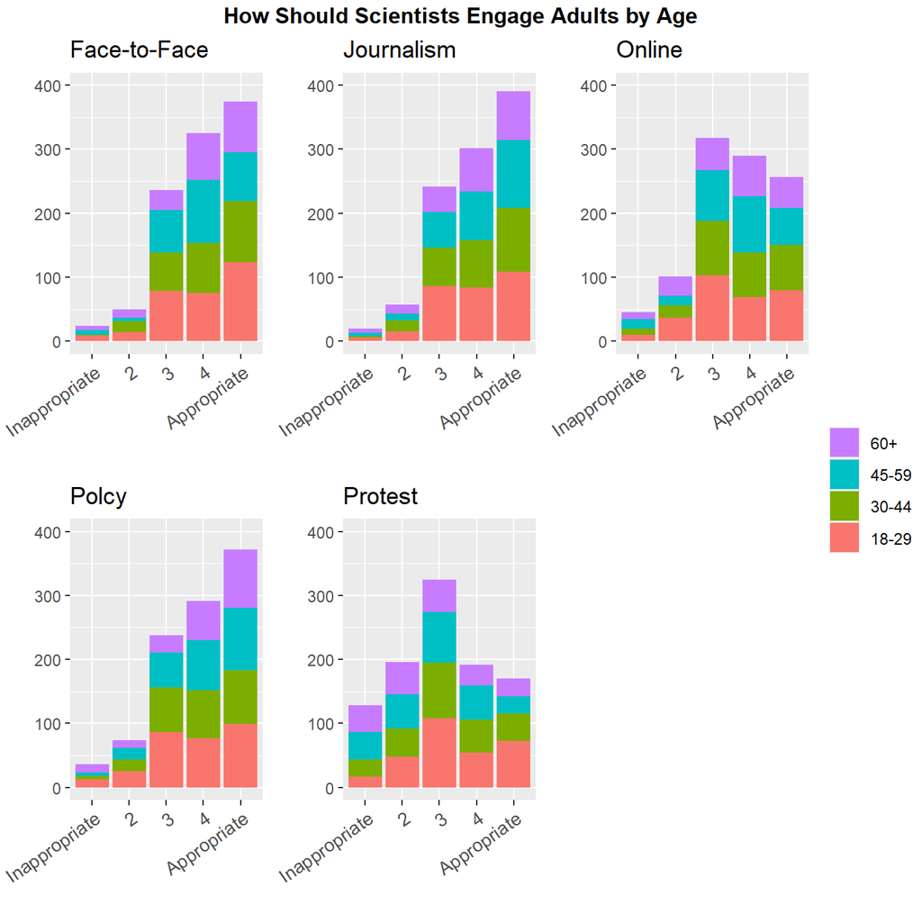

##### Communication Development

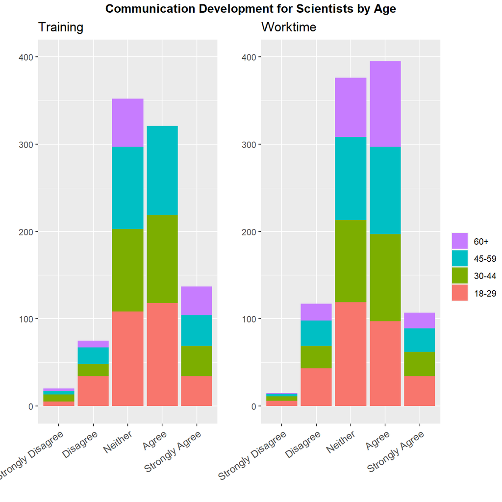

#### Education Level

##### Goals

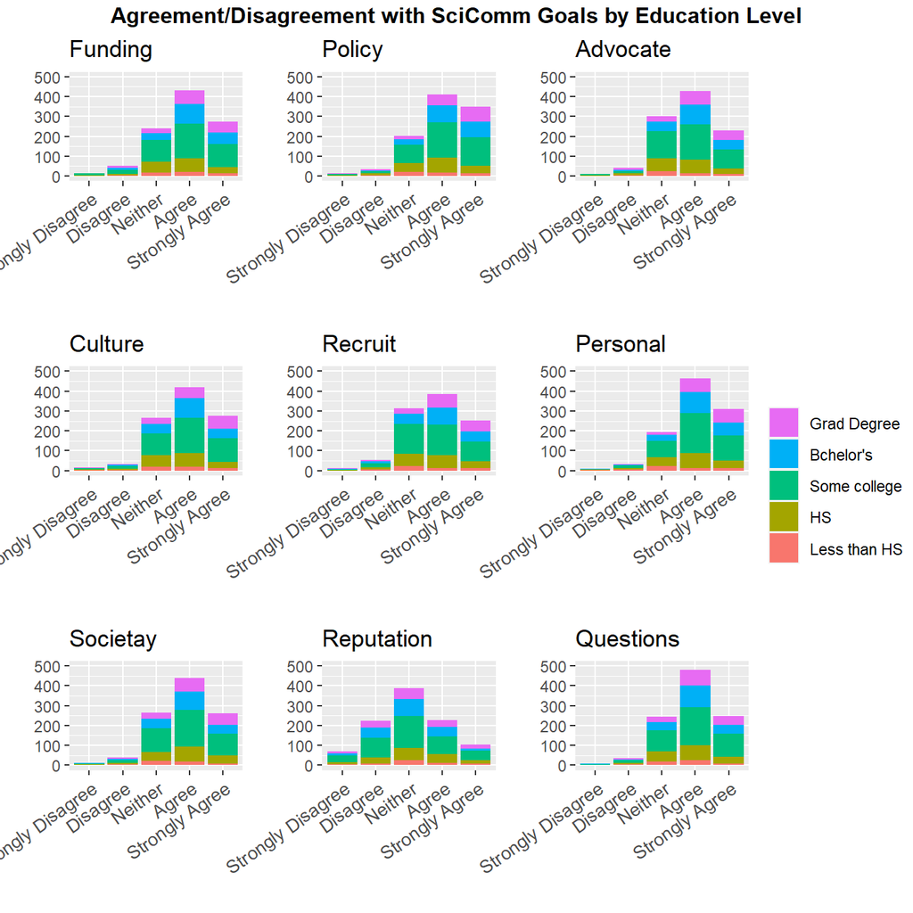

##### Objectives

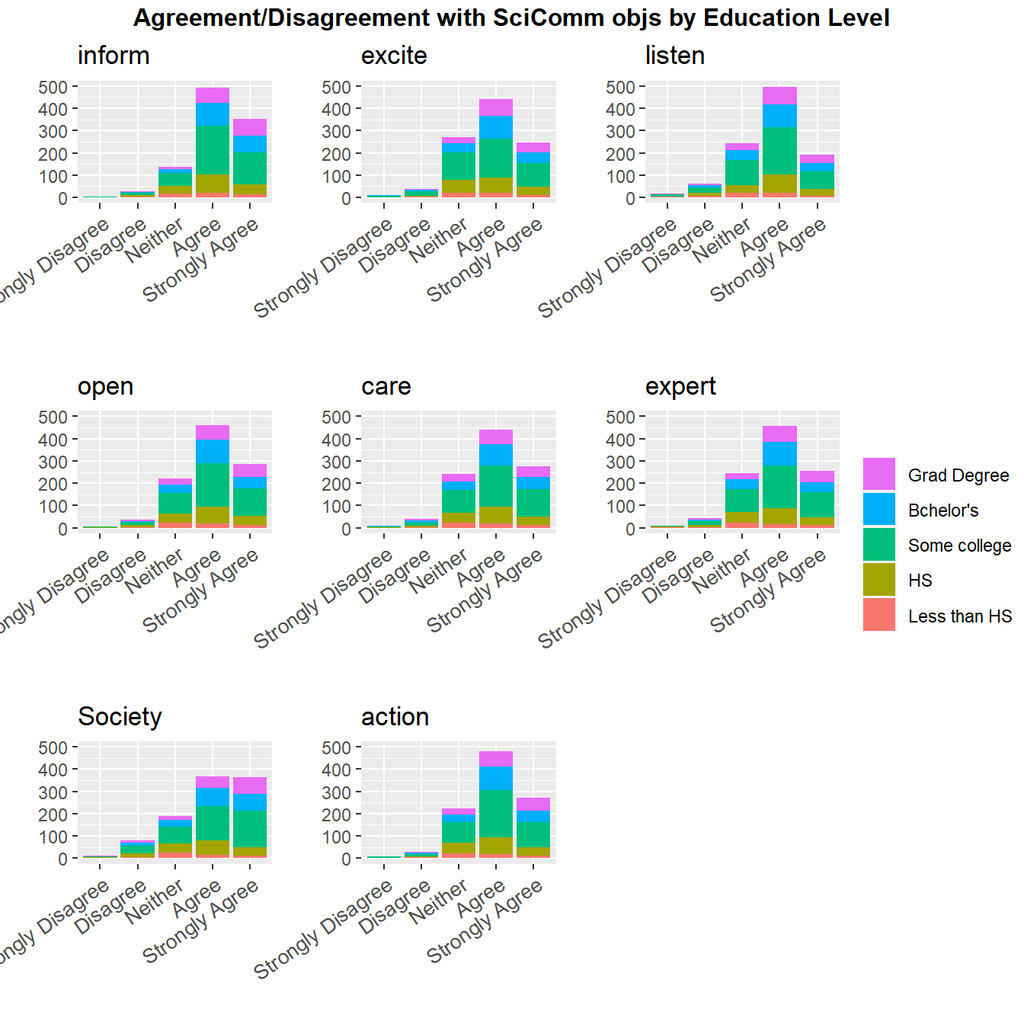

##### Tactics

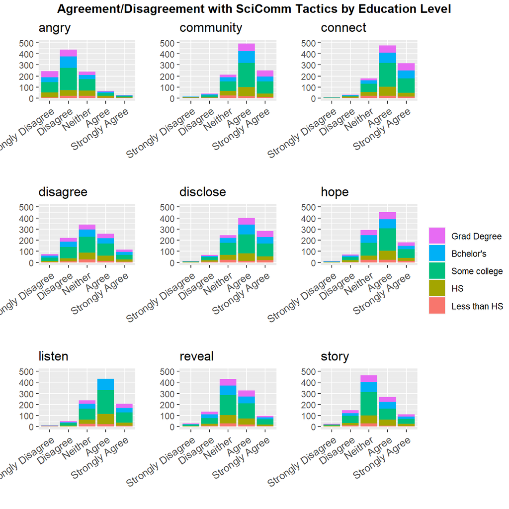

##### METI

Muenster Epistemic Trustworthiness Index

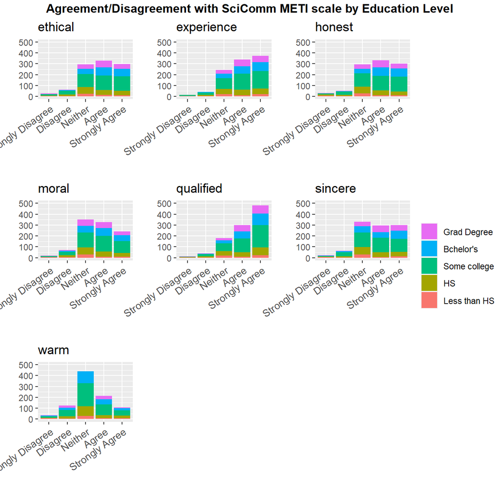

##### Science Media

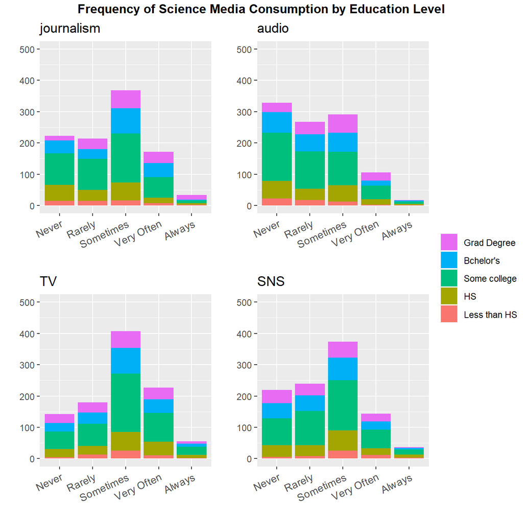

##### Mode of Enagement

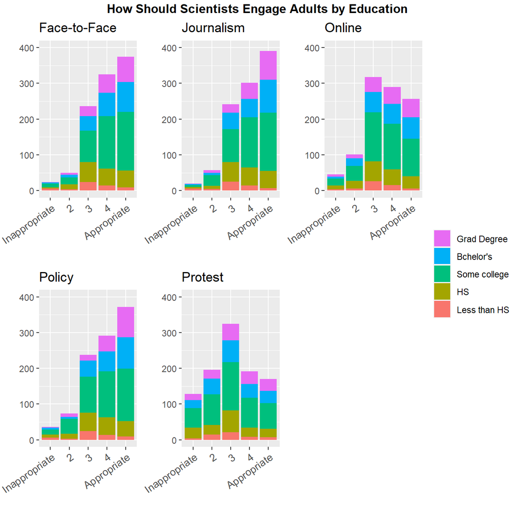

##### Communication Development

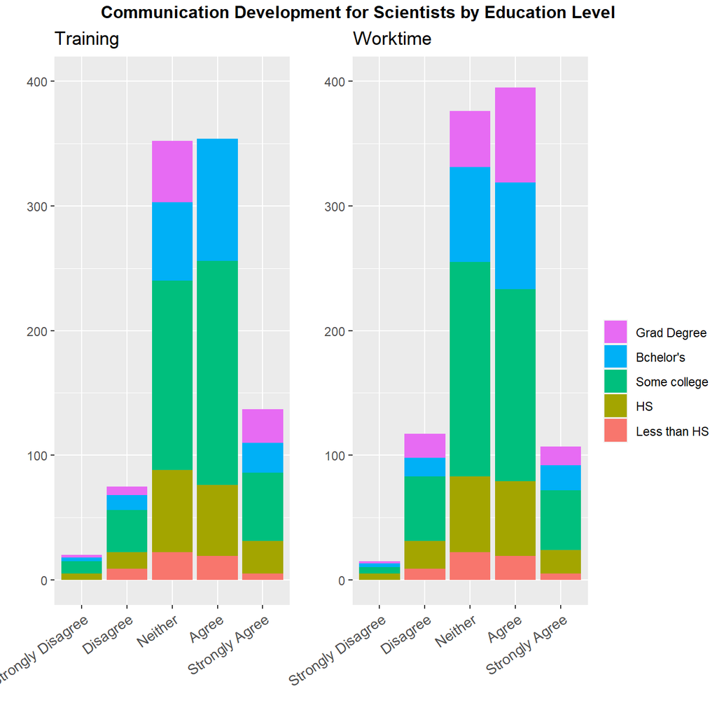

#### Race & Ethnicity

##### Goals

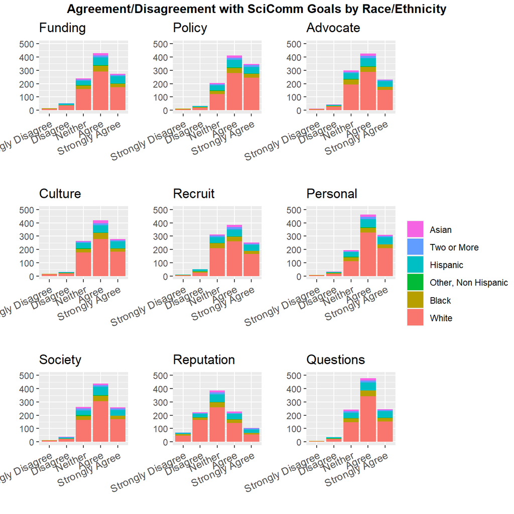

##### Objectives

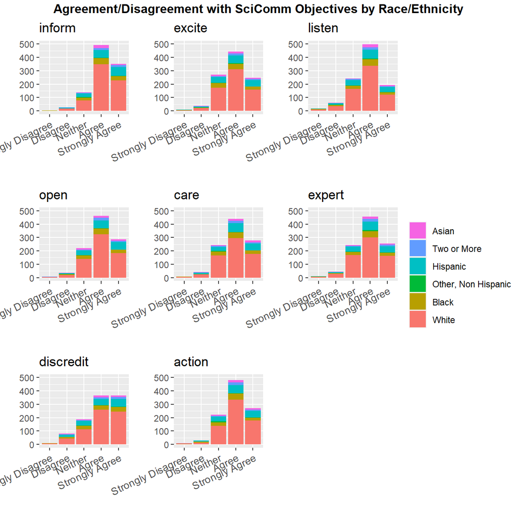

##### Tactics

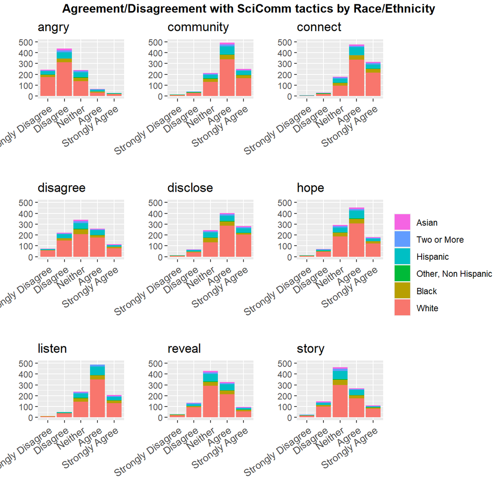